# Analysis of Covariance

## Analysis of covariance

- ANOVA: explanatory variables categorical (divide data into groups)
- traditionally, analysis of covariance has categorical $x$’s plus one numerical $x$ (“covariate”) to be adjusted for.
- `lm` handles this too.
- Simple example: two treatments (drugs) (`a` and `b`), with before and after scores.
- Does knowing before score and/or treatment help to predict after score?
- Is after score different by treatment/before score?

## Data: treatment, before, after

```
a 5 20
a 10 23
a 12 30
a 9 25
a 23 34
a 21 40
a 14 27
a 18 38
a 6 24
a 13 31
b 7 19
b 12 26
b 27 33
b 24 35
b 18 30
b 22 31
b 26 34
b 21 28
b 14 23
b 9 22
```

## Packages

```r
library(tidyverse)
library(broom)
library(marginaleffects)
```

the last of these for predictions.

## Read in data

```r
url <- "http://ritsokiguess.site/datafiles/ancova.txt"
prepost <- read_delim(url, " ")
prepost
```

| drug | before | after |
| --- | --- | --- |
| a | 5 | 20 |
| a | 10 | 23 |
| a | 12 | 30 |
| a | 9 | 25 |
| a | 23 | 34 |
| a | 21 | 40 |
| a | 14 | 27 |
| a | 18 | 38 |
| a | 6 | 24 |
| a | 13 | 31 |

[output cut: 10 more lines]

## Making a plot

```r
ggplot(prepost, aes(x = before, y = after, colour = drug)) +
  geom_point() + geom_smooth(method = "lm")
```

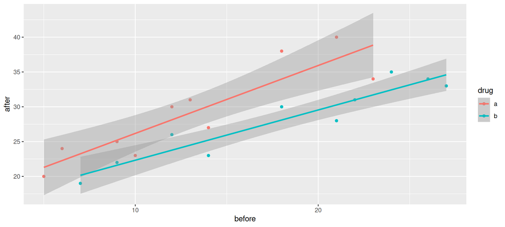

## Comments

- As before score goes up, after score goes up.
- Red points (drug A) generally above blue points (drug B), for comparable before score.
- Suggests before score effect *and* drug effect.

## The means

```r
prepost %>%
  group_by(drug) %>%
  summarize(
    before_mean = mean(before),
    after_mean = mean(after)
  )
```

| drug | before_mean | after_mean |
| --- | --- | --- |
| a | 13.1 | 29.2 |
| b | 18.0 | 28.1 |

- Mean “after” score slightly higher for treatment A.
- Mean “before” score much higher for treatment B.
- Greater *improvement* on treatment A.

## Testing for interaction

```r
prepost.1 <- lm(after ~ before * drug, data = prepost)
drop1(prepost.1, test = "F")
```

|  | Df | Sum of Sq | RSS | AIC | F value | Pr(>F) |
| --- | --- | --- | --- | --- | --- | --- |
|  | NA | NA | 109.9831 | 42.09189 | NA | NA |
| before:drug | 1 | 12.33708 | 122.3202 | 42.21820 | 1.79476 | 0.1990662 |

- Interaction not significant. Will remove later.

## Predictions

Set up values to predict for, median and quartiles for `before`, the two `drug`s:

```r
new <- datagrid(before = c(9.75, 14, 21.25),
                drug = c("a", "b"), model = prepost.1)
new
```

| before | drug | rowid |
| --- | --- | --- |
| 9.75 | a | 1 |
| 9.75 | b | 2 |
| 14.00 | a | 3 |
| 14.00 | b | 4 |
| 21.25 | a | 5 |
| 21.25 | b | 6 |

## and then

```r
cbind(predictions(prepost.1, newdata = new)) %>%
  select(drug, before, estimate, conf.low, conf.high)
```

| drug | before | estimate | conf.low | conf.high |
| --- | --- | --- | --- | --- |
| a | 9.75 | 25.93250 | 24.05059 | 27.81442 |
| b | 9.75 | 22.14565 | 19.58681 | 24.70450 |
| a | 14.00 | 30.07784 | 28.43296 | 31.72271 |
| b | 14.00 | 25.21304 | 23.32649 | 27.09959 |
| a | 21.25 | 37.14929 | 34.32557 | 39.97300 |
| b | 21.25 | 30.44565 | 28.64373 | 32.24758 |

## Predictions (with interaction included), plotted

```r
plot_predictions(model = prepost.1,
                 condition = c("before", "drug"))
```

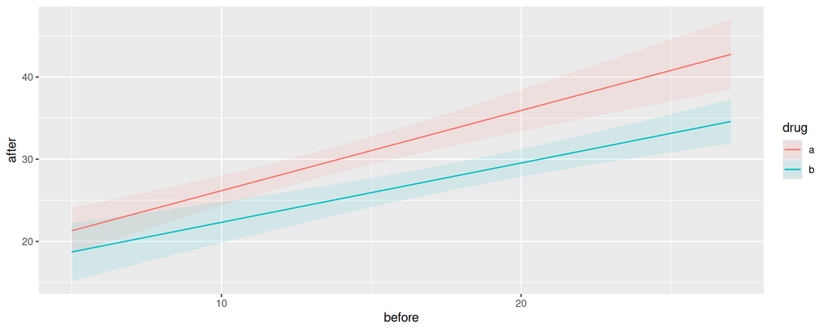

Lines almost parallel, but not quite.

## Taking out interaction

```r
prepost.2 <- update(prepost.1, . ~ . - before:drug)
drop1(prepost.2, test = "F")
```

|  | Df | Sum of Sq | RSS | AIC | F value | Pr(>F) |
| --- | --- | --- | --- | --- | --- | --- |
|  | NA | NA | 122.3202 | 42.21820 | NA | NA |
| before | 1 | 540.1798 | 662.5000 | 74.00577 | 75.07391 | 1.211339e-07 |
| drug | 1 | 115.3060 | 237.6262 | 53.49933 | 16.02516 | 9.209111e-04 |

- Take out non-significant interaction.
- `before` and `drug` strongly significant.
- Do predictions again and plot them.

## Predictions

```r
cbind(predictions(prepost.2, newdata = new)) %>%
  select(drug, before, estimate)
```

| drug | before | estimate |
| --- | --- | --- |
| a | 9.75 | 26.42794 |
| b | 9.75 | 21.27328 |
| a | 14.00 | 29.94473 |
| b | 14.00 | 24.79007 |
| a | 21.25 | 35.94397 |
| b | 21.25 | 30.78931 |

## Plot of predicted values

```r
plot_predictions(prepost.2, condition = c("before", "drug"))
```

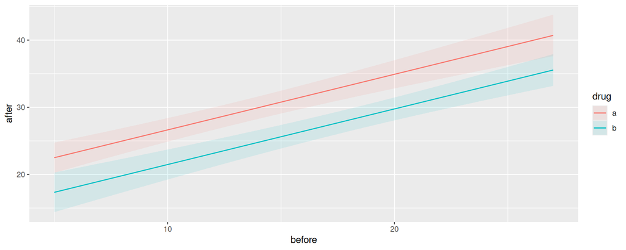

This time the lines are *exactly* parallel. No-interaction model forces them to have the same slope.

## Different look at model output

- `drop1(prepost.2)` tests for significant effect of before score and of drug, but doesn’t help with interpretation.
- `summary(prepost.2)` views as regression with slopes:

```r
summary(prepost.2)
```

```
Call:
lm(formula = after ~ before + drug, data = prepost)

Residuals:
    Min      1Q  Median      3Q     Max
-3.6348 -2.5099 -0.2038  1.8871  4.7453

Coefficients:
            Estimate Std. Error t value Pr(>|t|)
(Intercept)  18.3600     1.5115  12.147 8.35e-10 ***
before        0.8275     0.0955   8.665 1.21e-07 ***
drugb        -5.1547     1.2876  -4.003 0.000921 ***
---
Signif. codes:  0 '***' 0.001 '**' 0.01 '*' 0.05 '.' 0.1 ' ' 1

Residual standard error: 2.682 on 17 degrees of freedom
Multiple R-squared:  0.817, Adjusted R-squared:  0.7955
F-statistic: 37.96 on 2 and 17 DF,  p-value: 5.372e-07
```

## Understanding those slopes

```r
tidy(prepost.2)
```

| term | estimate | std.error | statistic | p.value |
| --- | --- | --- | --- | --- |
| (Intercept) | 18.3599949 | 1.51153263 | 12.146608 | 8.354496e-10 |
| before | 0.8274813 | 0.09550226 | 8.664520 | 1.211339e-07 |
| drugb | -5.1546584 | 1.28765245 | -4.003144 | 9.209111e-04 |

- `before` ordinary numerical variable; `drug` categorical.
- `lm` uses first category `druga` as baseline.
- Intercept is prediction of after score for before score 0 and *drug A*.
- `before` slope is predicted change in after score when before score increases by 1 (usual slope)
- Slope for `drugb` is *change* in predicted after score for being on drug B rather than drug A. Same for *any* before score (no interaction).

## Summary

- ANCOVA model: fits different regression line for each group, predicting response from covariate.
- ANCOVA model with interaction between factor and covariate allows different slopes for each line.
- Sometimes those lines can cross over!
- If interaction not significant, take out. Lines then parallel.
- With parallel lines, groups have consistent effect regardless of value of covariate.